# Ex 10: Simulation Studies

# 1. Background

In this vignette we show how to use WHAM for general simulation studies. There is some overlap with the 10th WHAM vignette on Operating models and MSE which may be replaced with this and other vignettes.

In this vignette we show how to:

- Simulate data from a fitted model with input derived from an ASAP3 dat file.
- Make an operating model, simulate data, and fit models.
- Fit models to data simulated from a different model.
- Make a default wham input file **without an ASAP3 dat file**.
- Configure different assumptions about the population for both the operating model and the estimating model.
- Do a closed-loop simulation with operating model, fitting an estimating model, generating catch advice and incorporating it into the operating model.

# 2. Setup and read in model input

Currently this is working out of the SSRTWG repository so make sure that your working directory is there.

Create a directory for this analysis:

```r
# devtools::install_github("timjmiller/wham", dependencies=TRUE, ref="devel")
source(file.path(here(),"wham_simulation","tutorial","helper.R")) #, local = knitr::knit_global()

# choose a location to save output, otherwise will be saved in working directory
#write.dir <- file.path(here(), "wham_simulation", "results") #SSRTWG results
#write.dir <- "choose/where/to/save/output"
#dir.create(write.dir)
#setwd(write.dir)
```

```r
wham.dir <- find.package("wham")
asap.file.path = file.path(wham.dir,"extdata","ex1_SNEMAYT.dat")
asap3 <- read_asap3_dat(asap.file.path)
```

Make an input and fit a model in wham. This model was also fit in the first example vignette.

```r
#define selectivity model
selectivity=list(
    model=rep("age-specific",3), #define selectivity model
    re=rep("none",3), #define selectivity random effects model
    #define initial/fixed values for age-specific selectivity
    initial_pars=list(c(0.5,0.5,0.5,1,1,0.5),c(0.5,0.5,0.5,1,0.5,0.5),c(0.5,1,1,1,0.5,0.5)),
    fix_pars=list(4:5,4,2:4)) #which ages to not estimate age-specfic selectivity parameters

NAA_re = list(
  sigma="rec", #random effects for recruitment only
  cor="iid", #random effects are independent
  recruit_model = 2) #mean recruitment is the only fixed effect parameter

input <- prepare_wham_input(
    asap3,
    selectivity = selectivity,
    NAA_re = NAA_re,
    model_name="Ex 1: SNEMA Yellowtail Flounder")

mod <- fit_wham(input, do.osa = F, do.retro=F, MakeADFun.silent = T) # don't do retro peels and OSA residuals, don't show output during optimization

names(mod)
```

```
#>  [1] "par"            "fn"             "gr"             "he"
#>  [5] "hessian"        "method"         "retape"         "env"
#>  [9] "report"         "simulate"       "years"          "years_full"
#> [13] "ages.lab"       "model_name"     "input"          "wham_version"
#> [17] "opt"            "date"           "dir"            "rep"
#> [21] "TMB_version"    "parList"        "final_gradient" "is_sdrep"
#> [25] "na_sdrep"       "runtime"        "sdrep"
```

Several of the elements in the object returned by `fit_wham` are those produced by `TMB::MakeADFun`. `mod$par` are the fixed effects or parameters over which the marginal likelihood is optimized. `mod$fn` is the function that returns the (Laplace approximation of) the negative marginal log-likelihood. `mod$gr` is the function that returns the gradient and `mod$he` returns the hessian. `mod$report` is a function that provides a list of output defined by REPORT() calls in the compiled cpp code and is already evaluated and provided by `mod$rep`. When available, `mod$sdrep` provides the hessian based standard errors for estimates from the model which is generated by the`TMB::sdreport` function.

```r
mod$sdrep #the standard errors of the fixed effects
```

```
#> sdreport(.) result
#>                    Estimate Std. Error
#> mean_rec_pars 10.1429738203 0.28530852
#> logit_q       -7.6512254853 0.07240598
#> logit_q       -8.3169815516 0.04787652
#> log_F1        -0.3010365597 0.10378094
#> F_devs         0.9285229416 0.13406941
#> F_devs        -0.0004773479 0.12741677
#> F_devs        -0.6333646293 0.14063536
#> F_devs         0.3545992256 0.15672409
#> F_devs         0.0007498385 0.14814836
#> F_devs        -0.1186869337 0.13952459
#> F_devs        -0.3135424185 0.13573691
#> F_devs        -0.3638492439 0.14032728
#> F_devs         0.3747984450 0.15107794
#> F_devs         0.4062432156 0.14131528
#> F_devs         0.3345658415 0.12315402
#> F_devs        -0.0926085078 0.12354231
#> F_devs        -0.0268561987 0.12975421
#> F_devs        -0.1547492535 0.13236249
#> F_devs        -0.5781912378 0.14060717
#> F_devs         0.0729322405 0.14723880
#> F_devs         0.5728244469 0.13078407
#> F_devs        -0.1306285071 0.11004614
#> F_devs        -0.2800617478 0.11369600
#> F_devs        -0.5485798871 0.12377094
#> F_devs         0.3737751961 0.13772134
#> F_devs        -0.9198984028 0.13376737
#> F_devs         0.2580256177 0.14685907
#> F_devs         0.4837561008 0.14669630
#> F_devs        -0.0965007661 0.14584155
#> F_devs         0.1868119330 0.15441950
#> F_devs        -0.0813445695 0.15144239
#> F_devs         0.1925950197 0.15297110
#> F_devs        -0.4368514619 0.14045843
#> F_devs        -0.1981206595 0.14133134
#> F_devs         0.2086433955 0.14571752
#> F_devs        -0.5430209898 0.13831609
#> F_devs        -0.2223686593 0.14787653
#> F_devs        -0.3312150849 0.14530564
```

[output cut: 14 more lines]

```
#> log_N1_pars   10.3051733768 0.13849860
#> log_NAA_sigma  0.2984650943 0.10907366
#> logit_selpars -3.2740083810 0.07972564
#> logit_selpars -3.5663837086 0.12201301
#> logit_selpars -0.4793729495 0.08493727
#> logit_selpars -0.6123439738 0.07866043
#> logit_selpars -0.0404455537 0.13774029
#> logit_selpars  1.5214280591 0.25870728
#> logit_selpars  1.3197981151 0.32315199
#> logit_selpars  1.8480537113 0.72656177
#> logit_selpars -0.3155761732 0.27025562
#> logit_selpars -1.7055860028 0.14892970
#> logit_selpars -1.8842728586 0.17675440
#> logit_selpars -2.2054297407 0.20103797
#> Maximum gradient component: 8.893997e-13
```

The important item for this vignette is `mod$simulate`

```r
mod$simulate
```

```
#> function (par = last.par, complete = FALSE)
#> {
#>     f(par, order = 0, type = "double", do_simulate = TRUE)
#>     sim <- as.list(reportenv)
#>     if (complete) {
#>         ans <- data
#>         ans[names(sim)] <- sim
#>     }
#>     else {
#>         ans <- sim
#>     }
#>     ans
#> }
#> <bytecode: 0x558556923740>
#> <environment: 0x55855692e150>
```

As we can see it is a function, but less apparent is that it will report anything using the `REPORT` calls, and most importantly, those within SIMULATE statements in the compiled cpp code. More information about simulation using the TMB package can be found [here](http://kaskr.github.io/adcomp/_book/Simulation.html). The WHAM cpp code is written to be able to simulate all observations and any random effects that are specified to be part of the particular model configuration. `mod$simulate` is what we use to simulate data for simulation studies. The `complete` argument tells the function to provide all data inputs whether they are simulated or not. For a wham model this would include important things like weight and maturity at age.

Here is a simple function that will simulate data from an operating model. It will fit the same model configuration to that data with the argument `self.fit=TRUE`.

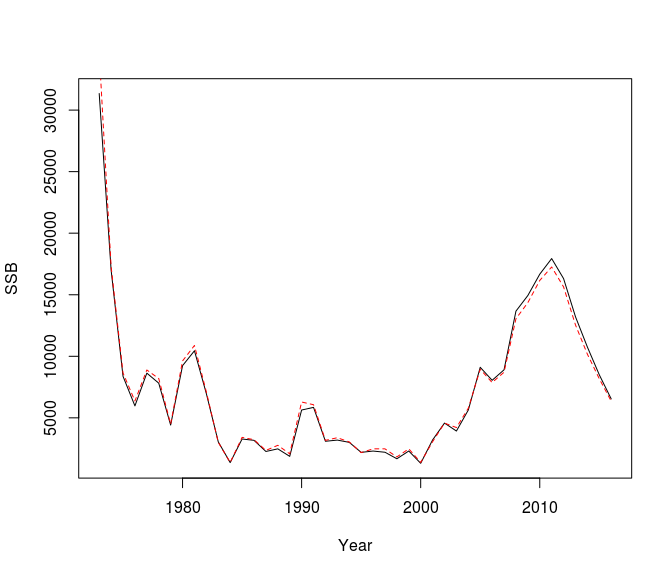

```r
sim_fn <- function(om, self.fit = FALSE){
    input <- om$input
    input$data = om$simulate(complete=TRUE)
    if(self.fit) {
      fit <- fit_wham(input, do.osa = F, do.retro = F, MakeADFun.silent = T)
      return(fit)
    } else return(input)
}
set.seed(123)
self_sim_fit <- sim_fn(mod, self.fit = TRUE)

plot(mod$years, self_sim_fit$input$data$SSB, type = 'l', ylab = "SSB", xlab = "Year")
lines(mod$years, self_sim_fit$rep$SSB, lty = 2, col = 'red')
```

Note that we just have to over-write the data component of the input with the values produced by `om$simulate(complete=TRUE)`. The call of `sim_fn` will fit the same model assumed to simulate the data. `fit_wham` saves the input used to fit the model and `om$simulate(complete=TRUE)` will provide all model output provided by `REPORT` calls in the cpp file. This includes the true SSB for the simulated data which can be compared with the values estimated from the simulated data.

Obviously for a simulation study many simulated data sets and model fits are needed for a given operating model. There are many ways to accomplish this task. It is often desirable to first simulate all the data before fitting each of them and to update results with each fit so that results are not lost if a catastrophic error occurs. Here is a lo-tech approach to simulating 100 data inputs and save information from fits of the same model to each of those data sets.

```r
set.seed(123)
sim_inputs <- replicate(100, sim_fn(mod), simplify=F)
res = list(reps = list(), par.est = list(), par.se = list(), adrep.est = list(), adrep.se =list())
for(i in 1:length(sim_inputs)){
  cat(paste0("i: ",i, "\n"))
  tfit = fit_wham(sim_inputs[[i]], do.osa = F, do.retro = F, MakeADFun.silent = T)
  res$reps[[i]] = tfit$rep
  res$par.est[[i]] = as.list(tfit$sdrep, "Estimate")
  res$par.se[[i]] = as.list(tfit$sdrep, "Std. Error")
  res$adrep.est[[i]] = as.list(tfit$sdrep, "Estimate", report = TRUE)
  res$adrep.se[[i]] = as.list(tfit$sdrep, "Std. Error", report = TRUE)
}
#these results have already been saved at wham_simulations/tutorial/vignette_10_res_1.RDS
saveRDS(res, file = file.path(here(), "wham_simulation","tutorial", "vignette_10_res_1.RDS"))
#these results have already been saved at wham_simulations/tutorial/vignette_10_sim_inputs.RDS
saveRDS(sim_inputs, file = file.path(here(), "wham_simulation","tutorial", "vignette_10_sim_inputs.RDS"))
```

The `replicate` function is used to generate 100 simulated inputs. Then we loop over the simulated data sets, fit each of them and save results for each fit. The results saved are the values provided by `REPORT` calls in the cpp file, the fixed effects MLEs (and PEBEs for random effects) and their standard errors, and the estimates for values provided by `ADREPORT` calls in the cpp file and their standard errors. See `?TMB::as.list.sdreport` for more information about accessing sdreport information like this. Saving these attributes will allow one to make inferences about bias of the maximum likelihood estimators, and corresponding standard errors, and confidence interval coverage for the basic parameters as well as a variety of derived model output (e.g., SSB, reference points).

The results above are available in the SSRTWG repository. Below is a plot of bias and 95% confidence intervals for SSB estimation.

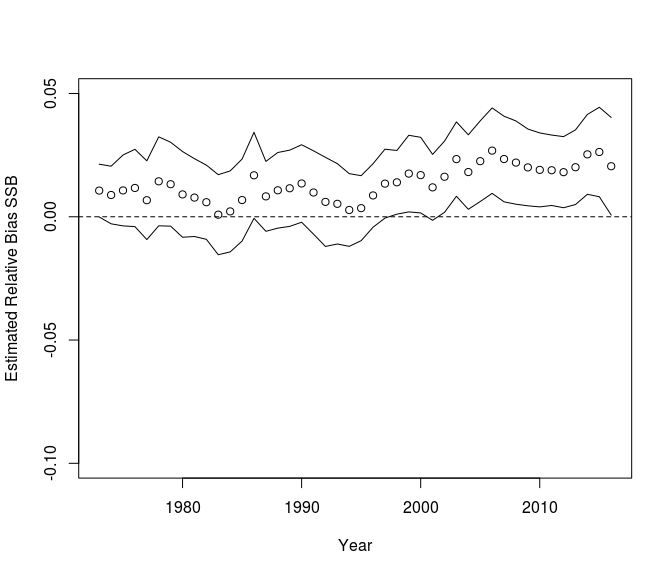

```r
res = readRDS(file.path(here(), "wham_simulation","tutorial", "vignette_10_res_1.RDS"))
sim_inputs = readRDS(file.path(here(), "wham_simulation","tutorial", "vignette_10_sim_inputs.RDS"))
true = sapply(sim_inputs, function(x) x$data$SSB)
est = sapply(res$rep, function(x) return(x$SSB))
SSB_rel_resid = est/true - 1
resid_cis = apply(SSB_rel_resid,1,mean) + apply(SSB_rel_resid,1,sd)*qnorm(0.975)*t(matrix(c(-1,1),2,44))/10

plot(mod$years, apply(SSB_rel_resid,1,mean), ylim = c(-0.1,0.05), ylab = "Estimated Relative Bias SSB", xlab = "Year")
lines(mod$years, resid_cis[,1])
lines(mod$years, resid_cis[,2])
abline(h = 0, lty = 2)
```

# 3. Fitting a model different from the operating model

When the fitted model is different from that used to simulate the data, there is a bit more work involved. Some components of the input used by `fit_wham` are important.

```r
names(input)
```

```
#> [1] "data"       "par"        "map"        "random"     "years"
#> [6] "years_full" "ages.lab"   "model_name" "asap3"
```

The first 4 elements of the input (`data`, `par`, `map`, `random`) are those used by TMB::MakeADFun to set up an objective function with derivative information (i.e.,gradient, hessian) used by the optimizer nlminb in fit_wham. We saw above that we could just swap the entire `data` element of the input when the estimation model is the same as the operating model. More generally though, components of these 4 input lists will need to be modified for the simulation studies where the operating model and estimation model are not the same. If the available data is the same for the operating and fitted model only a few elements of the input$data list need to be moved.

## 3a. An alternative age composition likelihood for the estimating model

Below is an example where an alternative likelihood for the age composition observations is assumed for the estimation model.

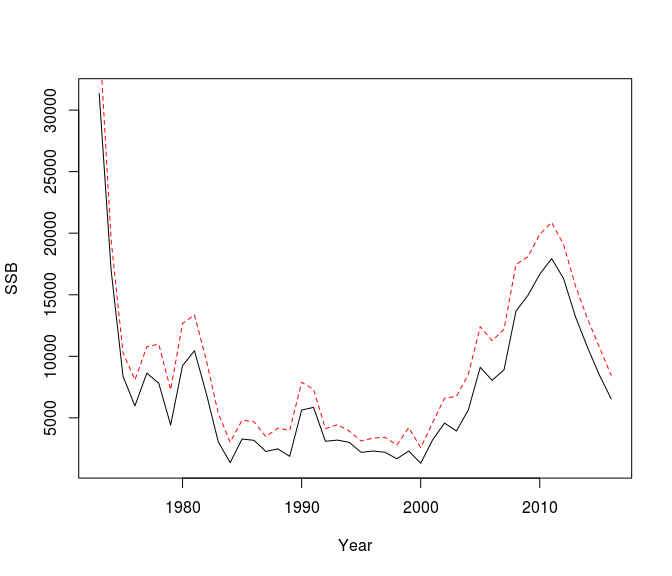

```r
input_em <- prepare_wham_input(
    asap3,
    recruit_model=2,
    model_name="Ex 1: SNEMA Yellowtail Flounder",
    selectivity=selectivity,
      NAA_re = NAA_re,
    age_comp = "logistic-normal-miss0") #the only difference from original input

#only replace the observations so that the other inputs for configuration are correct.
#IMPORTANT TO PROVIDE obsvec!
sim_fn = function(om, input, do.fit = FALSE){
    obs_names = c("agg_indices","agg_catch","catch_paa","index_paa", "Ecov_obs", "obsvec")
    om_data = om$simulate(complete = TRUE)
    input$data[obs_names] = om_data[obs_names]
    if(do.fit) {
        fit = fit_wham(input, do.osa = F, do.retro = F, MakeADFun.silent = TRUE)
        return(list(fit, om_data))
    } else return(list(input,om_data))
}
set.seed(123)
simfit = sim_fn(mod, input_em, do.fit = TRUE)
plot(mod$years, simfit[[2]]$SSB, type = 'l', ylab = "SSB", xlab = "Year")
lines(mod$years, simfit[[1]]$rep$SSB, lty = 2, col = 'red')
```

It is very important that the `obsvec` component of the simulated data is put into the input used for fitting because this holds the values in `agg_catch`, `agg_indices`, etc. in vector form for evaluating the likelihood. This is necessary to allow one-step-ahead residuals to be calculated using TMB. Note also because only a few elements are copied into `input$data` we need to save all of the true values of the simulated population as a separate component that is returned. For this particular simulation, SSB is estimated greater than the truth when the logistic normal is assumed but observations were generated by a multinomial. The same sort of approach as above can be used for simulating and fitting many data sets.

## 3b. Effective sample size assumption

Suppose we wanted to see how the estimating model behaves when we assume the multinomial age composition is more precise than it really is. Here we assume we want to use all of the same parameter estimates from the original model but change the necessary fixed data inputs. We modify the input with the appropriate data and populate `input$par` with the estimates from the original fit. Then we create this alternative operating model by calling `fit_wham(input, do.fit=F)` which creates the model configuration with the dll so that data can be simulated with this particular configuruation. Note that `do.fit=F` means that whatever parameter values are set (normally as initial and fixed values) in `input$par` will be used to simulate data. For the estimating model we can use the same input as the operating model except for changing the inputs for the effective sample size.

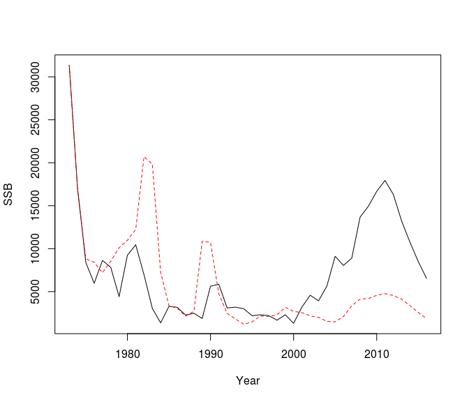

```r
sim_fn = function(om, Neff_om = 50, Neff_em = 200, do.fit = FALSE){
  om_input = om$input #the original input
    om_input$data$index_Neff[] = Neff_om #true effective sample size for the indices
    om_input$data$catch_Neff[] = Neff_om #true effective sample size for the indices
    om_input$par = as.list(om$sdrep, "Estimate") #assume parameter values estimated from original model
  om_alt = fit_wham(om_input, do.fit = F, MakeADFun.silent=T) #make unfitted model for simulating data
    om_data = om_alt$simulate(complete = TRUE)
    em_input = om_input #the same configuration other than Neff
    em_input$data$index_Neff[] = Neff_em #assumed effective sample size for the indices
    em_input$data$catch_Neff[] = Neff_em #assumed effective sample size for the indices
    obs_names = c("agg_indices","agg_catch","catch_paa","index_paa", "Ecov_obs", "obsvec")
    em_input$data[obs_names] = om_data[obs_names]
    if(do.fit) {
        fit = fit_wham(input, do.osa = F, do.retro = F, MakeADFun.silent = TRUE)
        return(list(fit, om_data))
    } else return(list(em_input,om_data))
}
set.seed(123)
simfit = sim_fn(mod, do.fit = TRUE)
plot(mod$years, simfit[[2]]$SSB, type = 'l', ylab = "SSB", xlab = "Year")
lines(mod$years, simfit[[1]]$rep$SSB, lty = 2, col = 'red')
```

Note that we could make the assumed effective sample size only incorrect for some subset of the fleets and indices. In the `sim_fn` function here we could have also just supplied all of `om_data` to `em_input$data` and then changed the Neff appropriately rather than just change the observations. Also, note that changing the Neff will only affect fits to those indices and fleets where the multinomial age comp assumption is made and where age composition observations are available.

The incorrect age composition precision has a large effect here!

## 3c. Population assumptions

Suppose we wanted to evaluate the effect of assuming a model with just random effects on recruitment when a full state-space model was the operating model. We will fit the full state-space model to the example data to get a configuration for the operating model then simulate data from it and fit the recruitment-only model to it.

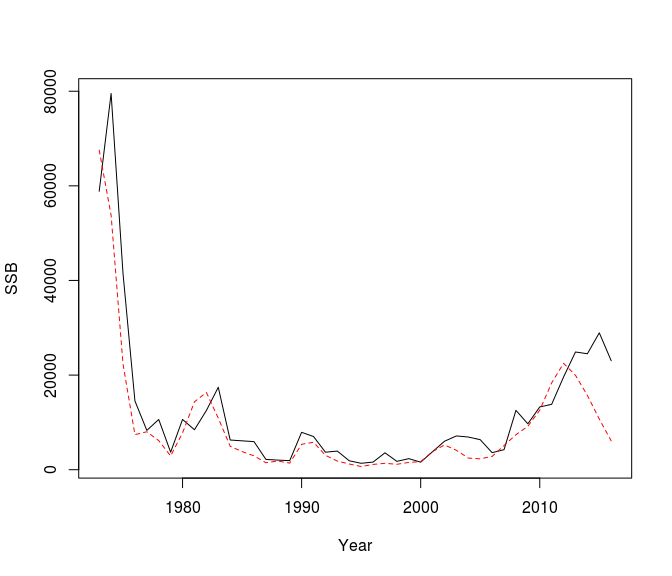

```r
NAA_re_om = list(
  sigma="rec+1", #random effects for recruitment and older age classes
  cor="iid", #random effects are independent
  recruit_model = 2) #mean recruitment is the only fixed effect parameter

NAA_re_em = list(
  sigma="rec", #random effects for recruitment only
  cor="iid", #random effects are independent
  recruit_model = 2) #mean recruitment is the only fixed effect parameter

input_om <- prepare_wham_input(
    asap3,
    selectivity = selectivity,
    NAA_re = NAA_re_om,
    model_name="Ex 1: SNEMA Yellowtail Flounder")

input_em <- prepare_wham_input(
    asap3,
    selectivity = selectivity,
    NAA_re = NAA_re_em,
    model_name="Ex 1: SNEMA Yellowtail Flounder")

om_ss <- fit_wham(input_om, do.osa = F, do.retro=F, MakeADFun.silent = T) # don't do retro peels and OSA residuals, don't show output during optimization

sim_fn = function(om, input, do.fit = FALSE){
    obs_names = c("agg_indices","agg_catch","catch_paa","index_paa", "Ecov_obs", "obsvec")
    om_data = om$simulate(complete = TRUE)
    input$data[obs_names] = om_data[obs_names]
    if(do.fit) {
        fit = fit_wham(input, do.osa = F, do.retro = F, MakeADFun.silent = TRUE)
        return(list(fit, om_data))
    } else return(list(input,om_data))
}
set.seed(123)
simfit = sim_fn(om_ss, input_em, do.fit = TRUE)
plot(om_ss$years, simfit[[2]]$SSB, type = 'l', ylab = "SSB", xlab = "Year")
lines(om_ss$years, simfit[[1]]$rep$SSB, lty = 2, col = 'red')
```

The scale of the population estimates from the recruitment-only model is similar to the true value, but it does not have sufficient flexibility to capture the inter-annual variability in the population size.

## 3d. Selectivity assumptions

Suppose the true selectivity is that estimated from the original model, but that we wanted to evaluate the effect of assuming logistic selectivity. Use the same `NAA_re` defined earlier but change the selectivity

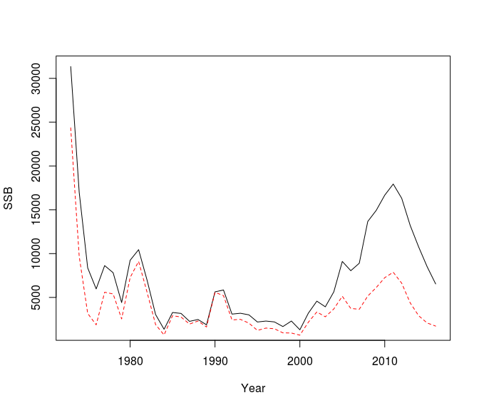

```r
selectivity_em = list(
  model = c(rep("logistic", input$data$n_fleets),rep("logistic", input$data$n_indices)),
  initial_pars = rep(list(c(5,1)), input$data$n_fleets + input$data$n_indices)) #fleet, index

input_em <- prepare_wham_input(
    asap3,
    selectivity = selectivity_em,
    NAA_re = NAA_re,
    model_name="Ex 1: SNEMA Yellowtail Flounder")
sim_fn = function(om, input, do.fit = FALSE){
    obs_names = c("agg_indices","agg_catch","catch_paa","index_paa", "Ecov_obs", "obsvec")
    om_data = om$simulate(complete = TRUE)
    input$data[obs_names] = om_data[obs_names]
    if(do.fit) {
        fit = fit_wham(input, do.osa = F, do.retro = F, MakeADFun.silent = TRUE)
        return(list(fit, om_data))
    } else return(list(input,om_data))
}
set.seed(123)
simfit = sim_fn(mod, input_em, do.fit = TRUE)
plot(mod$years, simfit[[2]]$SSB, type = 'l', ylab = "SSB", xlab = "Year")
lines(mod$years, simfit[[1]]$rep$SSB, lty = 2, col = 'red')
```

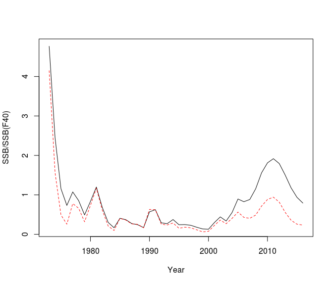

```r
plot(mod$years, simfit[[2]]$SSB/exp(simfit[[2]]$log_SSB_FXSPR), type = 'l', ylab = "SSB/SSB(F40)", xlab = "Year")
lines(mod$years, simfit[[1]]$rep$SSB/exp(simfit[[1]]$rep$log_SSB_FXSPR), lty = 2, col = 'red')
```

Lower SSB and stock status are estimated if logistic selectivity is assumed.

# 4. Creating a general operating model without an ASAP3 dat file

Note that the simulated data are conditioned on the fixed effects parameter values. If a model is fitted using `fit_wham` then the optimized values will be used `mod$simulate` for simulations, but these parameters can be specified without fitting the model and simulations can be more generally configured. Here we will use the functionality of `prepare_wham_input` to create a model object without an asap3 dat file and, then set parameter values we want to assume for the operating model

First we will read in a function `make_basic_info` that will make a list that can be provided to the `basic_info` argument of `prepare_wham_input`. The function is defined in the helper.R file and the elements of the output it provides are defined in the help file for `prepare_wham_input`.

```r
make_basic_info <- function(base_years = 1982:2021, ages = 1:10, Fhist = "updown", n_feedback_years = 0) { #changed years
    info <- list()
    info$ages <- ages
    info$years <- as.integer(base_years[1] - 1 + 1:(length(base_years) + n_feedback_years))
    info$n_fleets <- 1
    info$n_indices <- 1
    na <- length(info$ages)
    ny <- length(info$years)

    nby <- length(base_years)
    mid <- floor(nby/2)
    #up then down
    if(Fhist == "updown") info$F <- matrix(0.2 + c(seq(0,0.4,length.out = mid),seq(0.4,0,length.out=nby-mid)),nby, info$n_fleets)

    #down then up
    if(Fhist == "downup") info$F <- matrix(0.2 + c(seq(0.4,0,length.out = mid),seq(0,0.4,length.out=nby-mid)),nby, info$n_fleets)

    if(n_feedback_years>0) info$F <- rbind(info$F, info$F[rep(nby, n_feedback_years),, drop = F]) #same F as terminal year for feedback period

    info$catch_cv <- matrix(0.1, ny, info$n_fleets)
    info$catch_Neff <- matrix(200, ny, info$n_fleets)

    info$index_cv <- matrix(0.3, ny, info$n_indices)
    info$index_Neff <- matrix(100, ny, info$n_indices)
    info$fracyr_indices <- matrix(0.5, ny, info$n_indices)
    info$index_units <- rep(1, length(info$n_indices)) #biomass
    info$index_paa_units <- rep(2, length(info$n_indices)) #abundance

    info$maturity <- t(matrix(1/(1 + exp(-1*(1:na - na/2))), na, ny))

    L <- 100*(1-exp(-0.3*(1:na - 0)))
    W <- exp(-11)*L^3
    nwaa <- info$n_indices + info$n_fleets + 2
    info$waa <- array(NA, dim = c(nwaa, ny, na))
    for(i in 1:nwaa) info$waa[i,,] <- t(matrix(W, na, ny))

    info$fracyr_SSB <- rep(0.25,ny)
    info$q <- rep(0.3, info$n_indices)

    info$selblock_pointer_fleets <- t(matrix(1:info$n_fleets, info$n_fleets, ny))
    info$selblock_pointer_indices <- t(matrix(info$n_fleets + 1:info$n_indices, info$n_indices, ny))
    return(info)
}
```

Various attributes are specified in the make_basic_info function including the number of fleets and indices, the years over which the model spans, the number ages, precision of aggregate catch and index observations. Maturity and weight at age are defined as well as catchabilities for the indices, when they occur during the year and the selectiivty blocks to assign to each fleet and index.

Many of the other necessary attributes and initial parameters can be defined using the arguments `NAA_re`, `selectivity`, `M` to `prepare_wham_input`. Below we use specify logistic selectivity and associated parameters (a50 and /1slope), M = 0.2 and initial numbers at age and mean recruitment all using the lists supplied to these arguments of prepare_wham_input. However, nowhere have we specified a value for the standard deviation of the (log) recruitment random effects and so, the initial value (sd = 1) given in `prepare_wham_input` will be used. Importantly, `fit_wham` must be called with `do.fit=FALSE` to set up the model to be simulated with the parameter values specified rather than estimated.

```r
source(file.path(here(),"wham_simulation","tutorial","helper.R")) #, local = knitr::knit_global()
stock_om_info = make_basic_info()

selectivity_om = list(
  model = c(rep("logistic", stock_om_info$n_fleets),rep("logistic", stock_om_info$n_indices)),
  initial_pars = rep(list(c(5,1)), stock_om_info$n_fleets + stock_om_info$n_indices)) #fleet, index

M_om = list(initial_means = rep(0.2, length(stock_om_info$ages)))

NAA_re_om = list(
  N1_pars = exp(10)*exp(-(0:(length(stock_om_info$ages)-1))*M_om$initial_means[1]),
  sigma = "rec", #random about mean
  cor="iid", #random effects are independent
  use_steepness = 0,
  recruit_model = 2, #random effects with a constant mean
  recruit_pars = exp(10)
)

stock_om_input = prepare_wham_input(basic_info = stock_om_info, selectivity = selectivity_om, NAA_re = NAA_re_om, M = M_om)
```

```
#> [1] "number of selblocks, 2, is being determined by input$data$selblock_pointer_fleets and input$data$selblock_pointer_indices. Those should be 1,...,max(pointers)."
```

```r
stock_om = fit_wham(stock_om_input, do.fit = FALSE, MakeADFun.silent = TRUE)
```

As stated above, many of the parameter values are specified in the lists supplied to `prepare_wham_input`, but not all of them. In particular, we have not specified the variance parameter for the recruitment random effects so the default value for fitting a wham model is set.

```r
stock_om_input$par$log_NAA_sigma
```

```
#> [1] 0
```

which will mean a standard deviation = 1 is assumed. In general, the parameters defining the variance and correlation of any random effects and any effects of environmental covariates currently need to be specified by changing the input returned by `prepare_wham_input`.

## 4a. Setting NAA random effects variance parameters.

There are two parameter elements that we need to consider when using these random effects: `log_NAA_sigma` as mentioned above and `trans_NAA_rho` which defines the autocorrelation parameters on a logit scale with the parameter bounds of (-1,1). The latter need to be specified when the `cor` element of the `NAA_re` list is not `'iid'`. So here we will consider a 2d AR1 autoregressing model for the numbers at age random effects to demonstrate setting the parameters. We will suppose that we want to assume standard deviations of 0.6 for recruitment and 0.2 for older ages, and correlations of 0.4 temporally and 0.7 with age.

```r
stock_om_info = make_basic_info()

M_om = list(initial_means = rep(0.2, length(stock_om_info$ages)))

selectivity_om = list(
  model = c(rep("logistic", stock_om_info$n_fleets),rep("logistic", stock_om_info$n_indices)),
  initial_pars = rep(list(c(5,1)), stock_om_info$n_fleets + stock_om_info$n_indices)) #fleet, index

NAA_re_om = list(
  N1_pars = exp(10)*exp(-(0:(length(stock_om_info$ages)-1))*M_om$initial_means[1]),
  sigma = "rec+1", #random about mean
  cor="2dar1", #random effects correlated among age classes and across time (separably)
  use_steepness = 0,
  recruit_model = 2, #random effects with a constant mean
  recruit_pars = exp(10)
)

stock_om_input = prepare_wham_input(basic_info = stock_om_info, selectivity = selectivity_om, NAA_re = NAA_re_om, M = M_om)
```

```
#> [1] "number of selblocks, 2, is being determined by input$data$selblock_pointer_fleets and input$data$selblock_pointer_indices. Those should be 1,...,max(pointers)."
```

```r
stock_om_input$par$log_NAA_sigma
```

```
#> [1] 0 0
```

```r
stock_om_input$par$log_NAA_sigma = log(c(0.6,0.2))
stock_om_input$par$log_NAA_sigma
```

```
#> [1] -0.5108256 -1.6094379
```

```r
stock_om_input$par$trans_NAA_rho
```

```
#> [1] 0 0
```

```r
stock_om_input$par$trans_NAA_rho = wham:::gen.logit(c(0.7,0.4), -1, 1) #age first, year second
stock_om_input$par$trans_NAA_rho
```

```
#> [1] 1.7346011 0.8472979
```

Note we made use of an unexported function from the wham package that will do the transformation of parameters estimated on the logit scale. Not also, that the correlation parameter for age is first and that for time is second in the `trans_NAA_rho` vector. If `cor = 'ar1_a'` then we would only change the first parameter in `trans_NAA_rho` and if `cor = 'ar1_y'` we would only change the second parameter. Leaving the other value at zero makes those correlation parameters zero and the random effects independent in the appropriate way. Now when `stock_om$simulate()` is called the variability will be as we specified.

## 4b. Setting M random effects variance parameters

M random effects assumptions are similar to the NAA random effects, but the parameter names are different. For M there is a single vector (`M_repars`) of 3 values that defines the transformed M variance and autoregressing parameters: standard deviation, correlation with age, correlation with year. Here we assume we have random effects on recruitment and on natural mortality. As above, we define the general model to have 2d autocorrelation of M random effects for the most general case with variance of the (log) M random effects = 0.1 and correlations with age and time of 0.7 and 0.4.

```r
stock_om_info = make_basic_info()

M_om = list(
  model = "constant", # a single mean M for all ages
  initial_means = 0.2,
  re = "2dar1")

selectivity_om = list(
  model = c(rep("logistic", stock_om_info$n_fleets),rep("logistic", stock_om_info$n_indices)),
  initial_pars = rep(list(c(5,1)), stock_om_info$n_fleets + stock_om_info$n_indices)) #fleet, index

NAA_re_om = list(
  N1_pars = exp(10)*exp(-(0:(length(stock_om_info$ages)-1))*M_om$initial_means[1]),
  sigma = "rec", #random about mean
  use_steepness = 0,
  recruit_model = 2, #random effects with a constant mean
  recruit_pars = exp(10)
)

stock_om_input = prepare_wham_input(basic_info = stock_om_info, selectivity = selectivity_om, NAA_re = NAA_re_om, M = M_om)
```

```
#> [1] "number of selblocks, 2, is being determined by input$data$selblock_pointer_fleets and input$data$selblock_pointer_indices. Those should be 1,...,max(pointers)."
```

```r
stock_om_input$par$log_NAA_sigma
```

```
#> [1] 0
```

```r
stock_om_input$par$log_NAA_sigma = log(0.6)
stock_om_input$par$log_NAA_sigma
```

```
#> [1] -0.5108256
```

```r
stock_om_input$par$M_repars
```

```
#> [1] -2.302585  0.000000  0.000000
```

```r
stock_om_input$par$M_repars = c(log(0.1), wham:::gen.logit(c(0.7,0.4),-1,1))
stock_om_input$par$M_repars
```

```
#> [1] -2.3025851  1.7346011  0.8472979
```

```r
stock_om = fit_wham(stock_om_input, do.fit = FALSE, MakeADFun.silent = TRUE)
```

Note that the variance of the M random effects we are assuming is the same as the default value for estimation. Note also, that the mean of the M autoregressing random effects is defined by the `initial_means` component of the `M` argument to `prepare_wham_input` and it is not estimated by default. To estimate the mean of the M random effects at age, or just estimate a constant M without random effects, specify the `M$est_ages` argument to `prepare_wham_input`. There is a difference from numbers at age in how random effects for M are specified. If `M$re = "ar_a"` then there are only `n_ages` random effects that are constant over time. Similarly for `M$re = "ar_y"`, there are `n_years_model` random effects that are used for each age class. However, Setting the correlation parameters when `M$re = "ar_a"` or `M$re = "ar_y"` is analogous to the description for numbers at age random effects. To get `ar_a` or `ar_y` models analogous to numbers at age, one would have to specify `M$re = "2dar1"` and change `map$M_repars` to fix the appropriate parameter fixed at 0. To force random effects for certain age classes to be the same, one would also have to configure `map$M_re` appropriately.

```r
M_om = list(
  model = "constant", # a single mean M for all ages
  initial_means = 0.2,
  est_ages = 1, #must be 1 when model = "constant"
  re = "2dar1")
```

## 4c. Setting selectivity random effects variance parameters

Setting the variance parameters for selectivity is analogous to that for natural mortality random effects. The important difference is that the parameter defining the random effects variance parameters (`sel_repars`) is a matrix with rows for each selectivity block and the columns as defined for `M_repars`. Here we have two selectivity blocks: one for the fleet and one for the index. We will assume that the variance parameter for the fleet is 0.4 and that for the index is 0.1, but they both have the same correlation parameters with age and time: 0.7 and 0.4.

```r
stock_om_info = make_basic_info()

M_om = list(
  model = "constant", # a single mean M for all ages
  initial_means = 0.2)

selectivity_om = list(
  model = c(rep("logistic", stock_om_info$n_fleets),rep("logistic", stock_om_info$n_indices)),
  initial_pars = rep(list(c(5,1)), stock_om_info$n_fleets + stock_om_info$n_indices),
  re = rep("2dar1", stock_om_info$n_fleets + stock_om_info$n_indices))

NAA_re_om = list(
  N1_pars = exp(10)*exp(-(0:(length(stock_om_info$ages)-1))*M_om$initial_means[1]),
  sigma = "rec", #random about mean
  use_steepness = 0,
  recruit_model = 2, #random effects with a constant mean
  recruit_pars = exp(10)
)

stock_om_input = prepare_wham_input(basic_info = stock_om_info, selectivity = selectivity_om, NAA_re = NAA_re_om, M = M_om)
```

```
#> [1] "number of selblocks, 2, is being determined by input$data$selblock_pointer_fleets and input$data$selblock_pointer_indices. Those should be 1,...,max(pointers)."
```

```r
stock_om_input$par$log_NAA_sigma
```

```
#> [1] 0
```

```r
stock_om_input$par$log_NAA_sigma = log(0.6)
stock_om_input$par$log_NAA_sigma
```

```
#> [1] -0.5108256
```

```r
stock_om_input$par$sel_repars
```

```
#>           [,1] [,2] [,3]
#> [1,] -2.302585    0    0
#> [2,] -2.302585    0    0
```

```r
stock_om_input$par$sel_repars[1,] = c(log(0.4), wham:::gen.logit(c(0.7,0.4),-1,1))
stock_om_input$par$sel_repars[2,] = c(log(0.1), wham:::gen.logit(c(0.7,0.4),-1,1))
stock_om_input$par$sel_repars
```

```
#>            [,1]     [,2]      [,3]
#> [1,] -0.9162907 1.734601 0.8472979
#> [2,] -2.3025851 1.734601 0.8472979
```

```r
stock_om = fit_wham(stock_om_input, do.fit = FALSE, MakeADFun.silent = TRUE)
```

Note in this case where we assume logistic selectivity and 2D AR1 random effects, the correlation with “age” is actually just the correlation of the two logistic selectivity parameters on their estimated/transformed scale. Also, differing from natural mortality the mean parameters for the selectivity random effects (`logit_selpars`) are estimated by default.

## 4d. Setting catchability random effects variance parameters.

Setting the variance parameters for catchability is analogous to that for natural mortality and selectivity random effects. The parameters defining the variance and correlation of the annual catchability are defined in `q_repars` which is a matrix with rows corresponding to different indices and 2 columns for the standard deviation and correlation. The mean of the process is defined and estimated in the `logit_q` parameter which is defined in the `make_basic_info` function. Here we will assume the transformed catchability is an AR1 process with standard deviation 0.1 and autocorrelation = 0.5.

```r
stock_om_info = make_basic_info()

M_om = list(
  model = "constant", # a single mean M for all ages
  initial_means = 0.2)

selectivity_om = list(
  model = c(rep("logistic", stock_om_info$n_fleets),rep("logistic", stock_om_info$n_indices)),
  initial_pars = rep(list(c(5,1)), stock_om_info$n_fleets + stock_om_info$n_indices),
  re = rep("2dar1", stock_om_info$n_fleets + stock_om_info$n_indices))

NAA_re_om = list(
  N1_pars = exp(10)*exp(-(0:(length(stock_om_info$ages)-1))*M_om$initial_means[1]),
  sigma = "rec", #random about mean
  use_steepness = 0,
  recruit_model = 2, #random effects with a constant mean
  recruit_pars = exp(10)
)

catchability_om = list(re = "ar1") #could also define the mean q parameter here.

stock_om_input = prepare_wham_input(basic_info = stock_om_info, selectivity = selectivity_om, NAA_re = NAA_re_om, M = M_om, catchability = catchability_om)
```

```
#> [1] "number of selblocks, 2, is being determined by input$data$selblock_pointer_fleets and input$data$selblock_pointer_indices. Those should be 1,...,max(pointers)."
```

```r
stock_om_input$par$log_NAA_sigma
```

```
#> [1] 0
```

```r
stock_om_input$par$log_NAA_sigma = log(0.6)
stock_om_input$par$log_NAA_sigma
```

```
#> [1] -0.5108256
```

```r
stock_om_input$par$q_repars
```

```
#>      [,1] [,2]
#> [1,]    0    0
```

```r
stock_om_input$par$q_repars[1,] = c(log(0.1), wham:::gen.logit(0.5,-1,1))
stock_om_input$par$q_repars
```

```
#>           [,1]     [,2]
#> [1,] -2.302585 1.098612
```

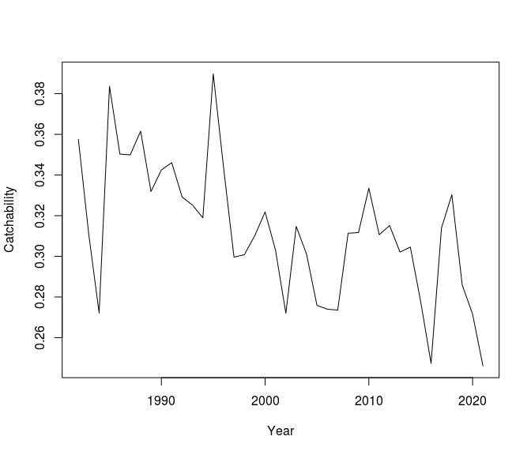

```r
stock_om = fit_wham(stock_om_input, do.fit = FALSE, MakeADFun.silent = TRUE)

set.seed(123)
sim_q = stock_om$simulate(complete=TRUE)

plot(stock_om$years, sim_q$q[,1], type = 'l', ylab = "Catchability", xlab = "Year")
```

## 4e. Setting effects of Environmental covariates.

When environmental effects are considered, there are assumptions to be made about the variance and any autocorrelation parameters for the random effects for the latent environmental process and the variance of the observation errors. The latter are specified in the the `ecov$log_sigma` argument to `prepare_wham_input`, but those for the random effects (`Ecov_process_pars`) must be specified after the call to `prepare_wham_input` like the other random effects described above. The value for the effect of the covariate on the population (`Ecov_beta`) must also be specified this way. The columns of `Ecov_process_pars` correspond to each environmental covariate being modeled and the number of rows is 3. If `ecov$process_model = "rw"` only the first two elements are used and represent the value in the first year and the conditional standard deviation parameter of the random walk. When `ecov$process_model = "ar1"` the three elements correspond to mean, variance, and correlation parameters.

The `Ecov_beta` parameter is a 4-dimensional array to be able to use it across all possible types of effects in a wham model. The first dimension indicates where the effect will be applied: recruitment, natural mortality, index 1,… index n. The second dimension is the order of the polynomial effect of the covariate. The third dimension indicates which environmental covariate the effect is having on the population. The fourth dimension indicates which age class the effect is on (for natural mortality only).

As long as there is only a single environmental effect, we can change the appropriate element of the `Ecov_beta` array by using the `map$Ecov_beta` specification returned by `prepare_wham_input`. The `map$Ecov_beta` will be all `NA` except for the configured effects on the population and when there is just one there is no ambiguity. Otherwise, the 4 correct indices of the `Ecov_beta` array must be referenced appropriately for each effect.

We will assume that our errors on the observations of the environmental covariate have a standard deviation = 0.2, the latent process is AR1 with mean 0, standard deviation = 0.3 and correlation parameter 0.5. We will also assume the effect is on (log) recruitment (no stock-recruit function) and the size of the effect is `Ecov_beta = 0.3`.

```r
stock_om_info = make_basic_info()

#constand M fixed at 0.2
M_om = list(
  model = "constant", # a single mean M for all ages
  initial_means = 0.2)

#logistic selectivity for fleet and index
selectivity_om = list(
  model = c(rep("logistic", stock_om_info$n_fleets),rep("logistic", stock_om_info$n_indices)),
  initial_pars = rep(list(c(5,1)), stock_om_info$n_fleets + stock_om_info$n_indices))

NAA_re_om = list(
  N1_pars = exp(10)*exp(-(0:(length(stock_om_info$ages)-1))*M_om$initial_means[1]),
  sigma = "rec", #random about mean
  recruit_model = 2, #random effects with a constant mean
  recruit_pars = exp(10)
)

ecov_om = list(
    label = "Climate variable 1",
    process_model = "ar1",
    mean = matrix(0, length(stock_om_info$years), 1), #observations which will be simulated later
    logsigma = log(0.2),
    lag = 0,
    years = stock_om_info$years,
    use_obs = matrix(1,length(stock_om_info$years),1),
    where = "recruit",
    how = 1)

stock_om_input = prepare_wham_input(basic_info = stock_om_info, selectivity = selectivity_om, NAA_re = NAA_re_om, M = M_om, ecov = ecov_om)
```

```
#> [1] "number of selblocks, 2, is being determined by input$data$selblock_pointer_fleets and input$data$selblock_pointer_indices. Those should be 1,...,max(pointers)."
#> [1] "ecov$logsigma is numeric. Coercing to a matrix..."
#> Please check that the environmental covariates have been loaded and interpreted correctly.
#>
#>       Model years: 1982 to 2021
#>       Ecov years: 1982 to 2021
#>
#>     Ecov 1: Climate variable 1
#>           Controlling () effect on: recruitment
#>
#>           Model years:
#>         1982 1983 1984 1985 1986 1987 1988 1989 1990 1991 1992 1993 1994 1995 1996 1997
#> 1998 1999 2000 2001 2002 2003 2004 2005 2006 2007 2008 2009 2010 2011 2012 2013
#> 2014 2015 2016 2017 2018 2019 2020 2021
#> Lag: 0
#>         Ex: Climate variable 1 in 1982 affects recruitment in 1982
#>             Climate variable 1 in 2021 affects recruitment in 2021
#>
#>
```

```r
#same assumption as above about standard deviation of recruitment.
stock_om_input$par$log_NAA_sigma
```

```
#> [1] 0
```

```r
stock_om_input$par$log_NAA_sigma = log(0.6)
stock_om_input$par$log_NAA_sigma
```

```
#> [1] -0.5108256
```

```r
#set sd and rho of ecov processes
stock_om_input$par$Ecov_process_pars[] = c(0, log(0.3), wham:::gen.logit(0.5,-1,1)) #mean, log(sd), logit(0.5)
#set size of Ecov_beta
stock_om_input$par$Ecov_beta[!is.na(stock_om_input$map$Ecov_beta)] = 0.3
stock_om_input$par$Ecov_beta[1,1,1,] #all = 0.3, but only the first one is used and all values mapped to be equal.
```

```
#>  [1] 0.3 0.3 0.3 0.3 0.3 0.3 0.3 0.3 0.3 0.3
```

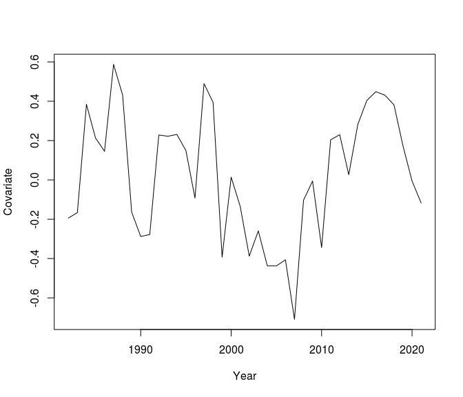

```r
stock_om = fit_wham(stock_om_input, do.fit = FALSE, MakeADFun.silent = TRUE)

set.seed(123)
sim_Ecov = stock_om$simulate(complete=TRUE)

plot(stock_om$years, sim_Ecov$Ecov_x, type = 'l', ylab = "Covariate", xlab = "Year")
```

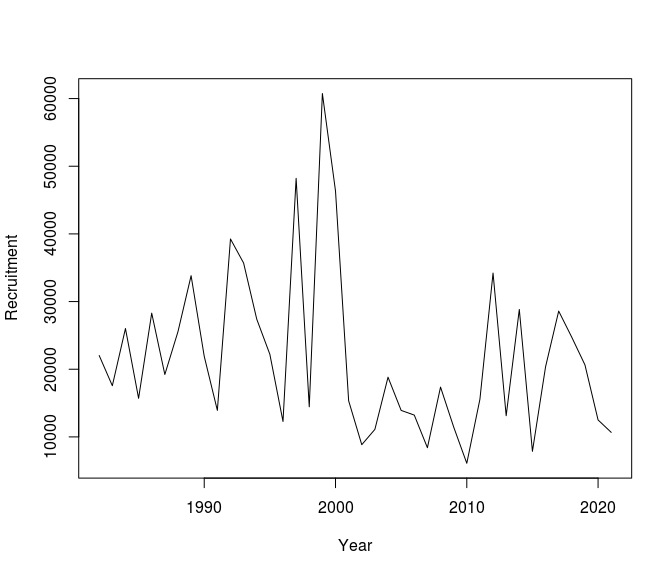

```r
plot(stock_om$years, sim_Ecov$NAA[,1], type = 'l', ylab = "Recruitment", xlab = "Year")
```

See the [catchability vignette](https://github.com/timjmiller/wham/blob/devel/vignettes/ex11_catchability.Rmd) for an example of simulating effects of multiple covariates on the population. Also see the [CPI and recruitment vignette](https://timjmiller.github.io/wham/articles/ex2_CPI_recruitment.html) for configuring effects on recruitment when a stock-recruit function is assumed.

## 4f. Estimation model with incorrect M assumption

Here we show how to set up an estimation model that assumes the wrong natural mortality rate (M = 0.3), but other aspects of the estimation model are consistent with the operating model. The `sim_fn` function will return the simulated population and data and either the input for the estimating model or the fitted estimation model.

```r
stock_om_input = prepare_wham_input(basic_info = stock_om_info, selectivity = selectivity_om, NAA_re = NAA_re_om, M = M_om)
```

```
#> [1] "number of selblocks, 2, is being determined by input$data$selblock_pointer_fleets and input$data$selblock_pointer_indices. Those should be 1,...,max(pointers)."
```

```r
#same assumption as above about standard deviation of recruitment.
stock_om_input$par$log_NAA_sigma
```

```
#> [1] 0
```

```r
stock_om_input$par$log_NAA_sigma = log(0.6)
stock_om_input$par$log_NAA_sigma
```

```
#> [1] -0.5108256
```

```r
stock_om = fit_wham(stock_om_input, do.fit = FALSE, MakeADFun.silent = TRUE)

M_em = list(
  model = "constant",
  initial_means = 0.3)

stock_em_input = prepare_wham_input(basic_info = stock_om_info, selectivity = selectivity_om, NAA_re = NAA_re_om, M = M_em)
```

```
#> [1] "number of selblocks, 2, is being determined by input$data$selblock_pointer_fleets and input$data$selblock_pointer_indices. Those should be 1,...,max(pointers)."
```

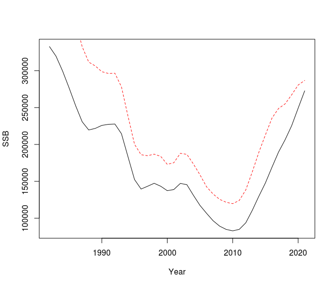

```r
sim_fn = function(om, em_input, do.fit = FALSE){
    obs_names = c("agg_indices","agg_catch","catch_paa","index_paa", "Ecov_obs", "obsvec")
    om_sim = om$simulate(complete = TRUE)
    em_input$data[obs_names] = om_sim[obs_names]
    if(do.fit) {
        em_fit = fit_wham(em_input, do.osa = F, do.retro = F, MakeADFun.silent = TRUE)
        return(list(em_fit, om_sim))
    } else return(list(em_input,om_sim))
}
set.seed(123)
simfit = sim_fn(stock_om, stock_em_input, do.fit = TRUE)
plot(stock_om$years, simfit[[2]]$SSB, type = 'l', ylab = "SSB", xlab = "Year")
lines(stock_om$years, simfit[[1]]$rep$SSB, lty = 2, col = 'red')
```

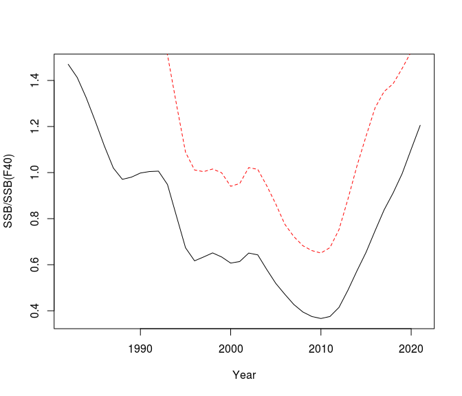

```r
plot(stock_om$years, simfit[[2]]$SSB/exp(simfit[[2]]$log_SSB_FXSPR), type = 'l', ylab = "SSB/SSB(F40)", xlab = "Year")
lines(stock_om$years, simfit[[1]]$rep$SSB/exp(simfit[[1]]$rep$log_SSB_FXSPR), lty = 2, col = 'red')
```

Both SSB and stock status are biased high when M is specified too large.

# 5. Closed-loop simulation

Here we will use the same operating and estimating model assumptions as above where the former is based on M = 0.2 and the latter assumes M = 0.3. To be applicable to a wider class of closed-loop simulations, it will be useful to create an operating model that includes a base period and a feedback period and an estimating model that uses data as it becomes available as time progresses through the feedback period. Previously, we had made use of the projection years as the feedback period, but selectivity random effects are not projected and environmental observations are not simulated in the projection period, both of which may be relevant. The operating model is also updated through the feedback period (redefining F and population state).

There are two other functions defined in the `helper.R` file for generating F from catch advice: `get_F_from_catch`, `update_om_F`. The first, is essentially just a solver for the F in the operating model for a catch that would be provided as management advice using the estimation model, but note that when the catch advice is not possible to actually take from the population or implies F greater than 10, F is set at 10.

```r
get_F_from_catch <- function(om, year, catch, Finit = 0.1, maxF = 10){
    rep = om$report()
    #print(year)
    naa = rep$NAA[year,]
    Maa = rep$MAA[year,]
    sel_tot = rep$FAA_tot[year,]/max(rep$FAA_tot[year,])
    waa = om$input$data$waa[om$input$data$waa_pointer_totcatch, year,]
    get_catch = function(log_F, naa, sel, waa, Maa){
        Faa = exp(log_F) * sel_tot
        Zaa = Maa + Faa
        Catch = 0
        for(a  in 1:length(naa)) Catch = Catch + waa[a] * naa[a] * Faa[a] *(1 - exp(-Zaa[a]))/Zaa[a];
        return(Catch)
    }
    obj = function(log_F) (catch - get_catch(log_F, naa, sel_tot, waa, Maa))^2
    opt = try(nlminb(log(Finit), obj))
    if(!is.character(opt)) Fsolve = exp(opt$par)[1] else Fsolve = maxF
    if(Fsolve>10) Fsolve = maxF
    print(paste0("Fsolve: ", Fsolve))
    return(Fsolve)
}
```

The second function uses `get_F_from_catch` to get the F and replace the F parameters in the operating model and update the population and observations

```r
update_om_F = function(om, year, catch){
    rep = om$report() #generate the reported values given the parameters
    year_ind = which(om$years == year) #index corresponding to year
    Fsolve = get_F_from_catch(om, year_ind, catch) #find the F for the catch advice
    #have to be careful if more than one fleet
    sel = rep$FAA[year_ind,,] #n_fleets x n_ages
    sel_all = sel/max(rep$FAA_tot[year_ind,]) #sum(sel_all) = 1
    FAA_all = Fsolve * rbind(sel_all)
    F_fleet = apply(FAA_all, 1, max) #full F for each fleet
    if(year_ind>1) om$input$par$F_devs[year_ind-1,] = log(F_fleet) - log(rep$F[year_ind-1,]) #change the F_dev to produce the right full F
    else om$input$par$log_F1 = log(F_fleet) #if year is the first year of the model, change F in year 1
    om <- fit_wham(om$input, do.fit = FALSE, MakeADFun.silent = TRUE)

}
```

First source the functions and create the stock operating model. We will specify a feedback period of 40 years beyond the 40 year base period.

```r
source(file.path(here(),"wham_simulation","tutorial","helper.R"))

stock_om_info = make_basic_info(base_years = 1982:2021, n_feedback_years = 40)
stock_om_input = prepare_wham_input(basic_info = stock_om_info, selectivity = selectivity_om, NAA_re = NAA_re_om, M = M_om)
```

```
#> [1] "number of selblocks, 2, is being determined by input$data$selblock_pointer_fleets and input$data$selblock_pointer_indices. Those should be 1,...,max(pointers)."
```

```r
stock_om <- fit_wham(stock_om_input, do.fit = FALSE, MakeADFun.silent = TRUE)
```

Now `stock_om` will be the operating model for a generic stock with biological inputs defined in the `make_basic_info` function. We need to define a function for updating the simulations from the operating model during the feedback period.

```r
update_om_fn = function(om, seed = 123, interval.info = NULL){
  obs_names = c("agg_indices","agg_catch","catch_paa","index_paa", "Ecov_obs", "obsvec")

  if(!is.null(interval.info)){ #iteratively update F over assessment interval for the given catch advice
    for(y in interval.info$years){
      om = update_om_F(om, year = y, catch = interval.info$catch) #put in the right F values
      set.seed(seed)
      om_sim = om$simulate(complete=TRUE) #resimulate the population and observations
      om$input$data[obs_names] = om_sim[obs_names] #update any simulated data
      om$input$par[om$input$random] = om_sim[om$input$random] #update any simulated random effects
      # reset the om
      om <- fit_wham(om$input, do.fit = F, MakeADFun.silent = TRUE)
    }
  } else { #otherwise just (re)generate the population
    set.seed(seed)
    om_sim = om$simulate(complete=TRUE) #resimulate the population and observations
    om$input$data[obs_names] = om_sim[obs_names] #update any simulated data
    om$input$par[om$input$random] = om_sim[om$input$random] #update any simulated random effects
    # reset the om
    om <- fit_wham(om$input, do.fit = F, MakeADFun.silent = TRUE)
  }
  return(om)
}
```

We now turn to defining the estimation model in a way such that the terminal year can be updated appropriately through the feedback period.

```r
make_em_input = function(M_em, sel_em, NAA_em, om_data, em_years){
  info = make_basic_info(base_years = em_years) #update the terminal year for the estimation model
  ind_em = 1:length(em_years) #year indices
  #fill in the data from the operating model simulation
  info$agg_catch = om_data$agg_catch[ind_em,, drop = F]
  info$agg_indices = om_data$agg_indices[ind_em,, drop = F]
  info$catch_paa = om_data$catch_paa[,ind_em,, drop = F]
  info$index_paa = om_data$index_paa[,ind_em,, drop = F]
  em_input = prepare_wham_input(basic_info = info, selectivity = sel_em, NAA_re = NAA_em, M = M_em)
}
```

We also need a function that will take the estimated model and generate catch advice from it.

```r
advice_fn = function(em){
  #make 5 year projections using F40. Use average SSB/R and YPR inputs over most recent 5 years
  proj_opts = list(n.yrs=5, use.FXSPR=TRUE, avg.yrs=tail(em$years,5))
  em_proj = project_wham(em, proj.opts = proj_opts, MakeADFun.silent=TRUE) #projected version of the em
  advice = mean(em_proj$rep$pred_catch[length(em_proj$years) + 1:5]) #mean of the projected catch over the next 5 years fishing at F40
  print(advice)
  return(advice)
}
```

Finally, we make a function that uses all the other functions and steps through the feedback period and updating the operating model, refitting the estimation model and generating the catch advice.

```r
loop_through_fn = function(om, M_em, selectivity_em, NAA_re_em, assess_years, assess_interval = assess.interval, base_years){
  catches = numeric() #save the catch advice
  for(i in assess_years){
    print(i)
    #make the input for the estimation model
    em_input = make_em_input(M_em, selectivity_em, NAA_re_em, om_data = om$input$data, em_years = base_years[1]:i)
    #fit the estimation model
    em = fit_wham(em_input, do.retro = FALSE, do.osa=F, MakeADFun.silent = TRUE) #no feedback period yet
    #make the catch advice
    advice = advice_fn(em)
    catches = c(catches, advice)
    #set the catch for the next assess_interval years
    interval.info = list(catch = advice, years = i + 1:assess_interval)
    #update the operating model with the right Fs and resimulate the data given those Fs
    om = update_om_fn(om, seed = 123, interval.info = interval.info)
  }
  return(list(om = om, em  = em, catches = catches))
}
```

```r
stock_om = update_om_fn(stock_om)

assess.interval = 4
base.years = make_basic_info()$years #no feedback period yet
first.year = head(base.years,1)
terminal.year = tail(base.years,1)
assess.years = seq(terminal.year, tail(stock_om$years,1)-assess.interval,by = assess.interval)
```

Running the loop function will take a little while, so we have saved some results for plotting.

```r
looped_res = loop_through_fn(stock_om, M_em = M_em, selectivity_em = selectivity_om, NAA_re_em = NAA_re, assess_years = assess.years, base_years = base.years)
saveRDS(looped_res$om$rep, file = file.path(here(), "wham_simulation", "tutorial", "vignette_10_looped_res.RDS"))
```

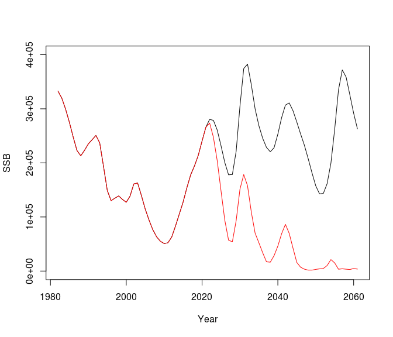

```r
looped_rep = readRDS(file = file.path(here(), "wham_simulation", "tutorial", "vignette_10_looped_res.RDS"))
plot(stock_om$years, stock_om$rep$SSB, type = "l", ylim = c(0,400000), ylab = "SSB", xlab = "Year")
lines(stock_om$years, looped_rep$SSB, col = "red")
```